# DATA607, Final Project - COVID19 Impact of US Businesses

Peter Fernandes

12/5/2020

# Introduction

COVID19 pandemic has definitely impacted in every aspect of our life in one way or the other with fewer and as well as larger implications. In this project I would like to study the impact of the COVID19 pandemic across businesses in USA. With the data from NASDAQ trading I will try to draw conclusions as to how the business sectors have been impacted.

# Data source

I tried different ways to get the data of NASDAQ and upon testing I found the below 2 data sources appropriate for me. I had to do data cleaning and transformation in order to fit the data for my analysis.

In order to get the SYMBOLS data I will use the API from NASDAQ. I will do the data cleaning in order to get the right data I want. I found this API when I was trying to scrape data from this page https://www.nasdaq.com/market-activity/stocks/screener

For getting the historical close price for the NASDAQ SYMBOLS I will make use of the package BatchGetSymbols

# Loading of the required libraries

```r
library(jsonlite)
library(httr)
library(DT)
library(BatchGetSymbols)
library(ggplot2)
library(ggpubr)
```

# COVID19 Impact on - Transportation sector

I will see how the Transportation sector has impacted by COVID19, I will see how did this sector behaved 3-months before March 2020 and 3-months after March 2020 considering March as the major lowdown month.

## Firstly, I will get all the symbols of Transportation sector by using the API

```r
#In the query string of the API limit parameter is set to total companies in Transportation sector and I get this from the webpage mentioned above. Exchange parameter is to set for which exchange house you want to query NASDAQ/ NYSE/ AMEX.

url <- paste0("https://api.nasdaq.com/api/screener/stocks?tableonly=true&limit=56&exchange=NASDAQ&sector=transportation")

symbols <- fromJSON(url, flatten = TRUE)
dfSymbols <- symbols$data$table$rows
#df$symbol
#View(df)
head(dfSymbols$symbol)
```

```
## [1] "AAL"   "AAWW"  "AIRT"  "AIRTP" "AIRTW" "ALGT"
```

## Secondly, I use the package in order to get the historical close price for the list of symbols from above.

```r
# set the first and last dates dates
first.date <- Sys.Date() - 371 #01-Dec-2019
last.date <- Sys.Date()- 159   #30-Jun-2020
freq.data <- 'monthly'

#call the function by setting the parameters

l.out <- BatchGetSymbols(tickers = dfSymbols$symbol,
                         first.date = first.date,
                         last.date = last.date,
                         freq.data = freq.data,
                         cache.folder = file.path(tempdir(),
                                                  'BGS_Cache') ) # cache in tempdir()

head(l.out$df.tickers)
```

```
## # A tibble: 6 x 10
##   ticker ref.date   volume price.open price.high price.low price.close
##   <chr>  <date>      <dbl>      <dbl>      <dbl>     <dbl>       <dbl>
## 1 AAL    2019-12-02 1.34e8       28.8       29.8     26.7         28.7
## 2 AAL    2020-01-02 2.27e8       29.0       29.3     25.4         26.8
## 3 AAL    2020-02-03 2.63e8       26.9       30.8     18.8         19.0
## 4 AAL    2020-03-02 1.30e9       19.0       19.8     10.0         12.2
## 5 AAL    2020-04-01 1.75e9       11.4       13.4      9.09        12.0
## 6 AAL    2020-05-01 1.38e9       11.4       12.6      8.25        10.5
## # ... with 3 more variables: price.adjusted <dbl>, ret.adjusted.prices <dbl>,
## #   ret.closing.prices <dbl>
```

## Thirdly, transform and clean up the data

```r
#Transform the data frame in order to get the per day max close price
dfTransform <- l.out$df.tickers %>% group_by(ref.date,ticker) %>%summarise(max(price.close))
#Rename the columns 1,2,3

names(dfTransform)[1]= "refdate"
names(dfTransform)[2]= "symbol"
names(dfTransform)[3]= "priceclose"

head(dfTransform)
```

```
## # A tibble: 6 x 3
## # Groups:   refdate [1]
##   refdate    symbol priceclose
##   <date>     <chr>       <dbl>
## 1 2019-12-02 AAL          28.7
## 2 2019-12-02 AAWW         27.6
## 3 2019-12-02 AIRT         20.2
## 4 2019-12-02 AIRTP        25.2
## 5 2019-12-02 ALGT        174.
## 6 2019-12-02 ARCB         27.6
```

## Plotting of the analysis over ggplot to visualize the data

We see from the below plot that almost all of the transportation companies had a downward trend during the March-April. As more and more people were confined to their homes transportation sector suffered.

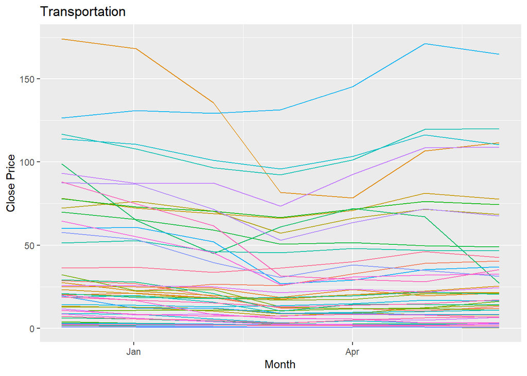

```r
ggplot(data = dfTransform, mapping = aes(x = refdate, y = priceclose)) + labs(x="Month", y="Close Price", title="Transportation")+
    geom_line( aes(color = symbol),show.legend = FALSE)
```

# COVID19 Impact on - Healthcare sector

I assume this is the one sector which would have benefited most during the pandemic. I will do the similar steps as done above and lets see how it concludes.

**From the plot below we see even in Healthcare sector there was largely downward trend expect for a few. It could be that even though the healthcare industry was doing well buying of the shares didn’t happen due to no money or fear among the people about the pandemic.**

```r
url <- paste0("https://api.nasdaq.com/api/screener/stocks?tableonly=true&limit=885&exchange=NASDAQ&sector=health_care")

symbols <- fromJSON(url, flatten = TRUE)
dfSymbols <- symbols$data$table$rows

head(dfSymbols$symbol)
```

```
## [1] "ABCM" "ABEO" "ABIO" "ABMD" "ABUS" "ACAD"
```

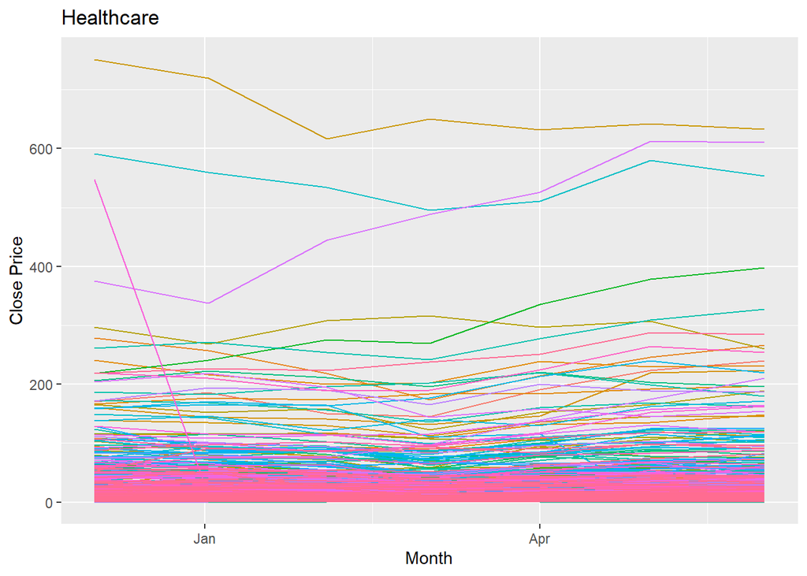

```r
first.date <- Sys.Date() - 371 #01-Dec-2019
last.date <- Sys.Date()- 159   #30-Jun-2020
freq.data <- 'monthly'

#call the function by setting the parameters

l.out <- BatchGetSymbols(tickers = dfSymbols$symbol,
                         first.date = first.date,
                         last.date = last.date,
                         freq.data = freq.data,
                         cache.folder = file.path(tempdir(),
                                                  'BGS_Cache') ) # cache in tempdir()

#head(l.out$df.tickers)
dfTransform <- l.out$df.tickers %>% group_by(ref.date,ticker) %>%summarise(max(price.close))

#Rename the columns 1,2,3

names(dfTransform)[1]= "refdate"
names(dfTransform)[2]= "symbol"
names(dfTransform)[3]= "priceclose"

ggplot(data = dfTransform, mapping = aes(x = refdate, y = priceclose)) + labs(x="Month", y="Close Price", title="Healthcare")+
    geom_line( aes(color = symbol),show.legend = FALSE)
```

# Impact on - Energy, Technology, Consumer services and Public utilities

```r
#ENERGY
url <- paste0("https://api.nasdaq.com/api/screener/stocks?tableonly=true&limit=57&exchange=NASDAQ&sector=energy")

symbols <- fromJSON(url, flatten = TRUE)
dfSymbols <- symbols$data$table$rows

first.date <- Sys.Date() - 371 #01-Dec-2019
last.date <- Sys.Date()- 159   #30-Jun-2020
freq.data <- 'monthly'

l.out <- BatchGetSymbols(tickers = dfSymbols$symbol,
                         first.date = first.date,
                         last.date = last.date,
                         freq.data = freq.data,
                         cache.folder = file.path(tempdir(),
                                                  'BGS_Cache') )
dfTransformE <- l.out$df.tickers %>% group_by(ref.date,ticker) %>%summarise(max(price.close))
names(dfTransformE)[1]= "refdate"
names(dfTransformE)[2]= "symbol"
names(dfTransformE)[3]= "priceclose"

#TECHNOLOGY
url <- paste0("https://api.nasdaq.com/api/screener/stocks?tableonly=true&limit=489&exchange=NASDAQ&sector=technology")

symbols <- fromJSON(url, flatten = TRUE)
dfSymbols <- symbols$data$table$rows

first.date <- Sys.Date() - 371 #01-Dec-2019
last.date <- Sys.Date()- 159   #30-Jun-2020
freq.data <- 'monthly'

l.out <- BatchGetSymbols(tickers = dfSymbols$symbol,
                         first.date = first.date,
                         last.date = last.date,
                         freq.data = freq.data,
                         cache.folder = file.path(tempdir(),
                                                  'BGS_Cache') )



dfTransformT <- l.out$df.tickers %>% group_by(ref.date,ticker) %>%summarise(max(price.close))

names(dfTransformT)[1]= "refdate"
names(dfTransformT)[2]= "symbol"
names(dfTransformT)[3]= "priceclose"

#Consumer services

url <- paste0("https://api.nasdaq.com/api/screener/stocks?tableonly=true&limit=376&exchange=NASDAQ&sector=consumer_services")

symbols <- fromJSON(url, flatten = TRUE)
dfSymbols <- symbols$data$table$rows

first.date <- Sys.Date() - 371 #01-Dec-2019
last.date <- Sys.Date()- 159   #30-Jun-2020
freq.data <- 'monthly'

l.out <- BatchGetSymbols(tickers = dfSymbols$symbol,
                         first.date = first.date,
                         last.date = last.date,
                         freq.data = freq.data,
                         cache.folder = file.path(tempdir(),
                                                  'BGS_Cache') )



dfTransformC <- l.out$df.tickers %>% group_by(ref.date,ticker) %>%summarise(max(price.close))

names(dfTransformC)[1]= "refdate"
names(dfTransformC)[2]= "symbol"
names(dfTransformC)[3]= "priceclose"

#Public utilities

url <- paste0("https://api.nasdaq.com/api/screener/stocks?tableonly=true&limit=65&exchange=NASDAQ&sector=public_utilities")

symbols <- fromJSON(url, flatten = TRUE)
dfSymbols <- symbols$data$table$rows

first.date <- Sys.Date() - 371 #01-Dec-2019
last.date <- Sys.Date()- 159   #30-Jun-2020
freq.data <- 'monthly'

l.out <- BatchGetSymbols(tickers = dfSymbols$symbol,
                         first.date = first.date,
                         last.date = last.date,
                         freq.data = freq.data,
                         cache.folder = file.path(tempdir(),
                                                  'BGS_Cache') )



dfTransformP <- l.out$df.tickers %>% group_by(ref.date,ticker) %>%summarise(max(price.close))

names(dfTransformP)[1]= "refdate"
names(dfTransformP)[2]= "symbol"
names(dfTransformP)[3]= "priceclose"
```

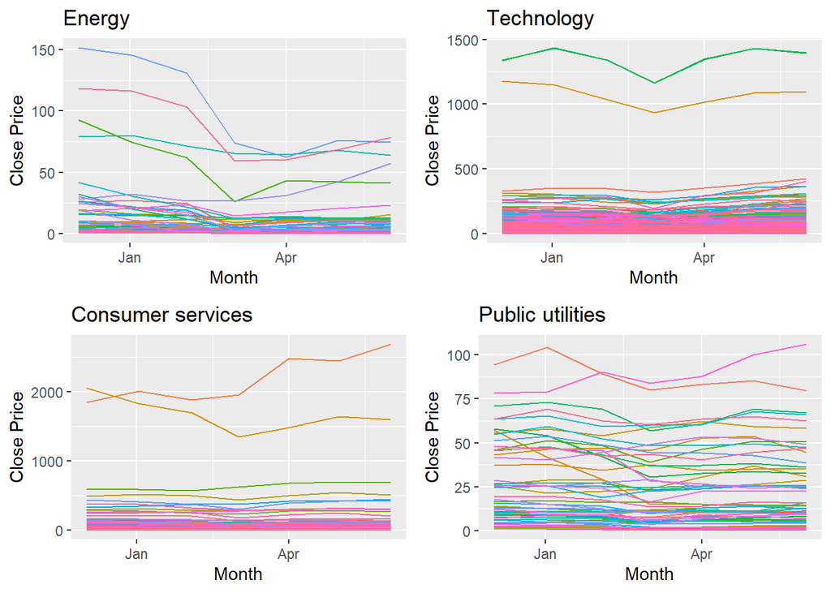

```r
energy <- ggplot(data = dfTransformE, mapping = aes(x = refdate, y = priceclose)) + labs(x="Month", y="Close Price", title="Energy")+
    geom_line( aes(color = symbol),show.legend = FALSE)

tech <- ggplot(data = dfTransformT, mapping = aes(x = refdate, y = priceclose)) + labs(x="Month", y="Close Price", title="Technology")+
    geom_line( aes(color = symbol),show.legend = FALSE)

cs <- ggplot(data = dfTransformC, mapping = aes(x = refdate, y = priceclose)) + labs(x="Month", y="Close Price", title="Consumer services")+
    geom_line( aes(color = symbol),show.legend = FALSE)

pu <- ggplot(data = dfTransformP, mapping = aes(x = refdate, y = priceclose)) + labs(x="Month", y="Close Price", title="Public utilities")+
    geom_line( aes(color = symbol),show.legend = FALSE)

sectors_plot <- ggarrange(energy, tech, cs, pu,

                    ncol = 2, nrow = 2)
sectors_plot
```